# OZNAL projekt 2

### 3.experiment: GPD a percentage expenditure ako prediktory

```r
# model
model = glm(status_oh ~ `percentage expenditure` + GDP, data = train_data)
summary(model)
```

```
##
## Call:
## glm(formula = status_oh ~ `percentage expenditure` + GDP, data = train_data)
##
## Coefficients:
##                           Estimate Std. Error t value Pr(>|t|)
## (Intercept)              9.042e-02  8.764e-03  10.316  < 2e-16 ***
## `percentage expenditure` 5.611e-05  9.331e-06   6.014 2.18e-09 ***
## GDP                      5.181e-06  1.437e-06   3.606 0.000319 ***
## ---
## Signif. codes:  0 '***' 0.001 '**' 0.01 '*' 0.05 '.' 0.1 ' ' 1
##
## (Dispersion parameter for gaussian family taken to be 0.1096413)
##
##     Null deviance: 272.10  on 1839  degrees of freedom
## Residual deviance: 201.41  on 1837  degrees of freedom
## AIC: 1159.3
##
## Number of Fisher Scoring iterations: 2
```

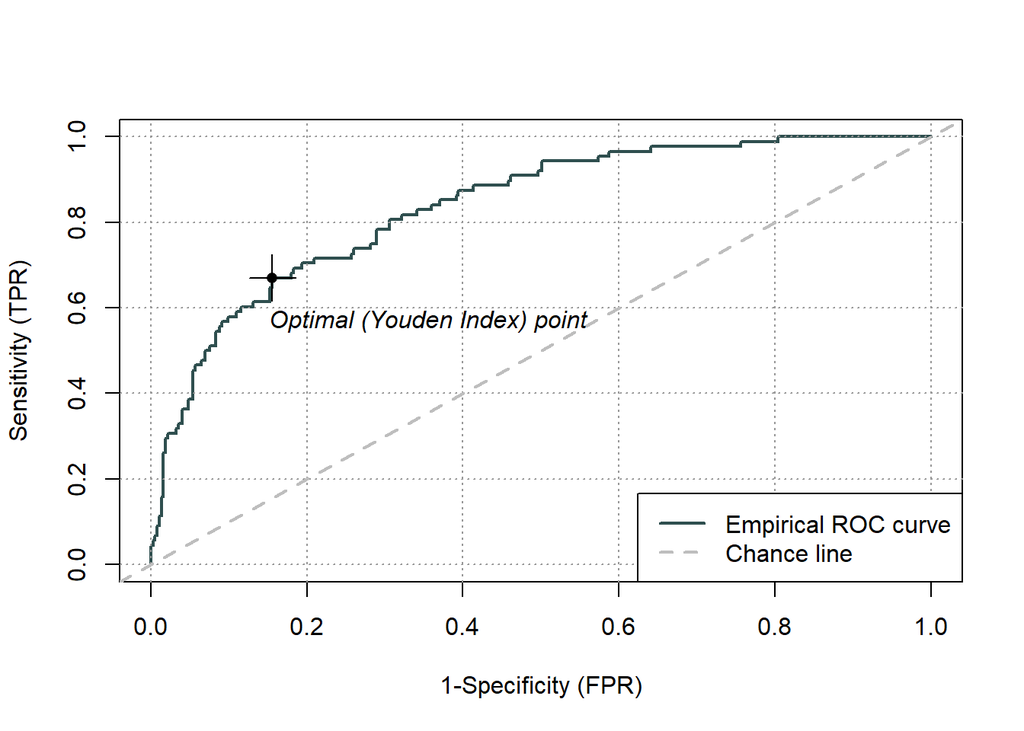

```r
predictions <- predict(model, test_data)

actual <- test_data$status_oh

# výpočet cut off hodnoty, ktorý naznačuje optimálny bod pre prahovu hodnotu, ktorá rozdeľuje predikcie na pozitívne a negatívne, čiže rozvojovú a rozvinutú krajinu.

roc = rocit(predictions, actual)
plot(roc)
```

```r
cutoff_index <- which.max(roc$TPR + (1 - roc$FPR) - 1)
optimal_cutoff <- roc$Cutoff[cutoff_index]
optimal_cutoff
```

```
## [1] 0.168071
```

```r
predicted_class <- ifelse(predictions >= optimal_cutoff, 1, 0)

# confussion matrix
caret::confusionMatrix(as.factor(predicted_class), as.factor(actual), positive = "1")
```

```
## Confusion Matrix and Statistics
##
##           Reference
## Prediction   0   1
##          0 315  29
##          1  58  59
##
##                Accuracy : 0.8113
##                  95% CI : (0.7725, 0.846)
##     No Information Rate : 0.8091
##     P-Value [Acc > NIR] : 0.481238
##
##                   Kappa : 0.4574
##
##  Mcnemar's Test P-Value : 0.002683
##
##             Sensitivity : 0.6705
##             Specificity : 0.8445
##          Pos Pred Value : 0.5043
##          Neg Pred Value : 0.9157
##              Prevalence : 0.1909
##          Detection Rate : 0.1280
##    Detection Prevalence : 0.2538
##       Balanced Accuracy : 0.7575
##
##        'Positive' Class : 1
##
```

Celkovo model naznačuje, že GDP a percentage expenditure sú významnými prediktormi rozvojového statusu krajiny, pričom vyššie GDP a percentage expenditure sú spojené s vyššou pravdepodobnosťou byť rozvinutou krajinou. H0 zamietame. Spravili sme cross tabulaciu a z confusion matrix vidíme, že náš model má 81,13% presnosť.

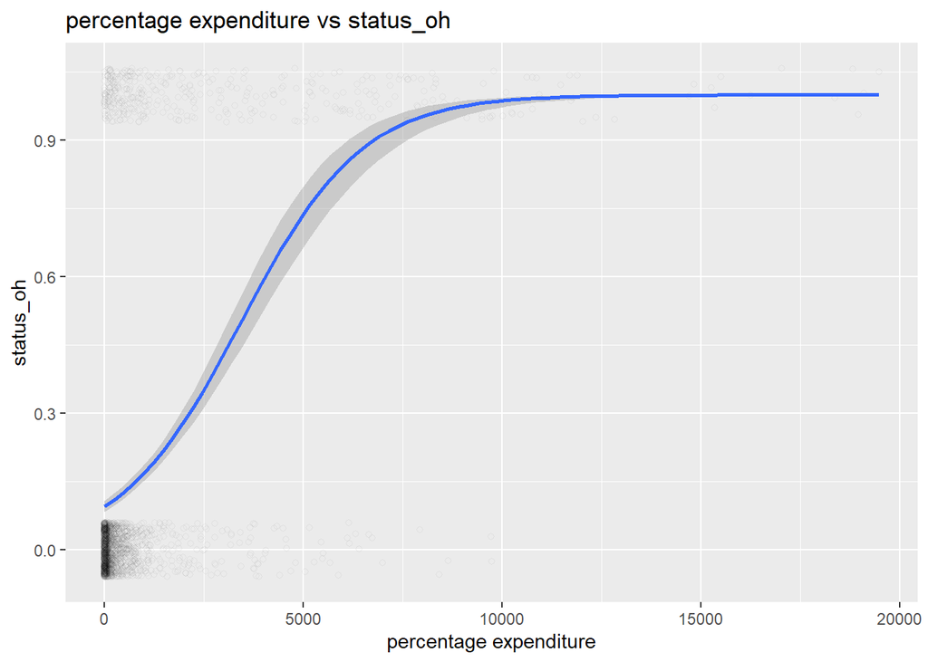

```r
data %>%
  ggplot(., aes(x = `percentage expenditure`, y = status_oh)) +  # Specify X and Y variables
  geom_point(position = position_jitter(width = 0.3, height = 0.06),
             alpha = 0.05,
             shape = 1,
             size = 1.5) +
  stat_smooth(method = glm, method.args = list(family = binomial)) +
  ggtitle("percentage expenditure vs status_oh")
```

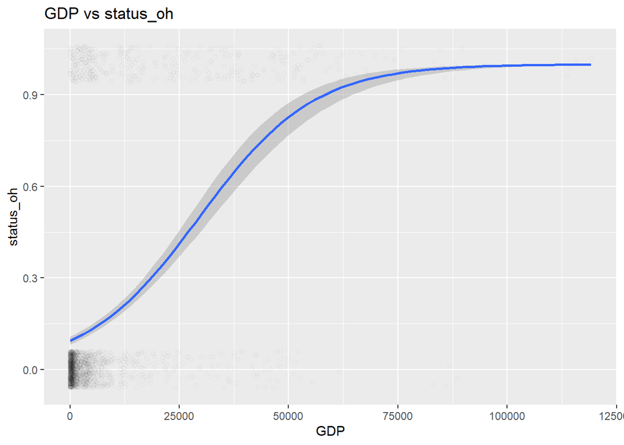

```r
data %>%
  ggplot(., aes(x = GDP, y = status_oh)) +  # Specify X and Y variables
  geom_point(position = position_jitter(width = 0.3, height = 0.06),
             alpha = 0.05,
             shape = 1,
             size = 1.5) +
  stat_smooth(method = glm, method.args = list(family = binomial)) +
  ggtitle("GDP vs status_oh")
```

percentage expendicture viac vplýva na status krajiny (rozvinutá/nerozvinutá) ako GDP z grafu pre logistickú funkciu, čo nám nakoniec hovorí aj samotný model.

# Radial SVM metóda

```r
library(e1071)

# Model
svm_model <- svm(status_oh ~ `percentage expenditure` + GDP, data = train_data, kernel = "radial")
summary(svm_model)
```

```
##
## Call:
## svm(formula = status_oh ~ `percentage expenditure` + GDP, data = train_data,
##     kernel = "radial")
##
##
## Parameters:
##    SVM-Type:  eps-regression
##  SVM-Kernel:  radial
##        cost:  1
##       gamma:  0.5
##     epsilon:  0.1
##
##
## Number of Support Vectors:  531
```

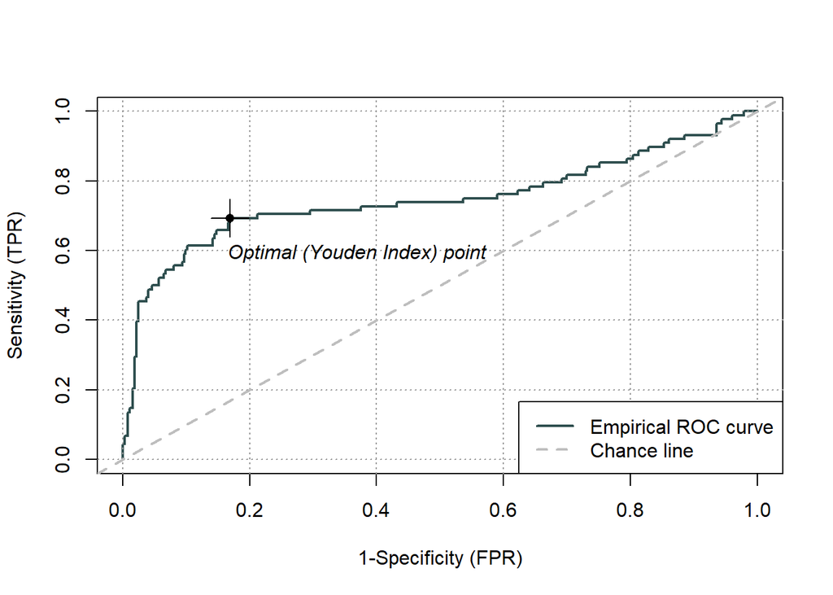

```r
# Predictions
svm_predictions <- predict(svm_model, test_data)

actual <- test_data$status_oh
roc_svm_rad = rocit(svm_predictions, actual)
plot(roc_svm_rad)
```

```r
cutoff_index <- which.max(roc_svm_rad$TPR + (1 - roc_svm_rad$FPR) - 1)
optimal_cutoff <- roc_svm_rad$Cutoff[cutoff_index]
optimal_cutoff
```

```
## [1] 0.03853527
```

```r
predicted_class_svm_rad <- ifelse(svm_predictions >= optimal_cutoff, 1, 0)

# Confusion matrix
confusionMatrix(as.factor(predicted_class_svm_rad), as.factor(test_data$status_oh))
```

```
## Confusion Matrix and Statistics
##
##           Reference
## Prediction   0   1
##          0 310  27
##          1  63  61
##
##                Accuracy : 0.8048
##                  95% CI : (0.7656, 0.84)
##     No Information Rate : 0.8091
##     P-Value [Acc > NIR] : 0.6207116
##
##                   Kappa : 0.4534
##
##  Mcnemar's Test P-Value : 0.0002249
##
##             Sensitivity : 0.8311
##             Specificity : 0.6932
##          Pos Pred Value : 0.9199
##          Neg Pred Value : 0.4919
##              Prevalence : 0.8091
##          Detection Rate : 0.6725
##    Detection Prevalence : 0.7310
##       Balanced Accuracy : 0.7621
##
##        'Positive' Class : 0
##
```

Accuracy: 80,48%. H0 zamietame. eps-regression - model sa snaží predpovedať spojitú premennú namiesto klasifikácie do dvoch tried, kedže nemáme kategorickú premennú.

# Linear SVM metóda

```r
# Model
svm_model <- svm(status_oh ~ `percentage expenditure` + GDP, data = train_data, kernel = "linear")
summary(svm_model)
```

```
##
## Call:
## svm(formula = status_oh ~ `percentage expenditure` + GDP, data = train_data,
##     kernel = "linear")
##
##
## Parameters:
##    SVM-Type:  eps-regression
##  SVM-Kernel:  linear
##        cost:  1
##       gamma:  0.5
##     epsilon:  0.1
##
##
## Number of Support Vectors:  620
```

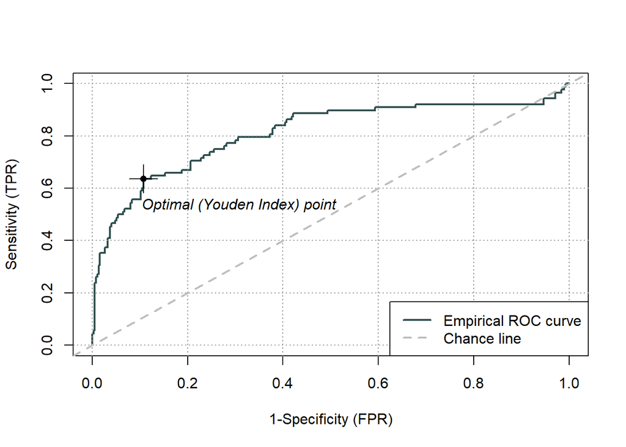

```r
# Predictions
svm_predictions <- predict(svm_model, test_data)

actual <- test_data$status_oh

roc_svm_ln = rocit(svm_predictions, actual)
plot(roc_svm_ln)
```

```r
cutoff_index <- which.max(roc_svm_ln$TPR + (1 - roc_svm_ln$FPR) - 1)
optimal_cutoff <- roc_svm_ln$Cutoff[cutoff_index]
optimal_cutoff
```

```
## [1] 0.0829257
```

```r
predicted_class_svm_ln <- ifelse(svm_predictions >= optimal_cutoff, 1, 0)

# Confusion matrix
confusionMatrix(as.factor(predicted_class_svm_ln), as.factor(test_data$status_oh))
```

```
## Confusion Matrix and Statistics
##
##           Reference
## Prediction   0   1
##          0 333  32
##          1  40  56
##
##                Accuracy : 0.8438
##                  95% CI : (0.8074, 0.8757)
##     No Information Rate : 0.8091
##     P-Value [Acc > NIR] : 0.03081
##
##                   Kappa : 0.5114
##
##  Mcnemar's Test P-Value : 0.40940
##
##             Sensitivity : 0.8928
##             Specificity : 0.6364
##          Pos Pred Value : 0.9123
##          Neg Pred Value : 0.5833
##              Prevalence : 0.8091
##          Detection Rate : 0.7223
##    Detection Prevalence : 0.7918
##       Balanced Accuracy : 0.7646
##
##        'Positive' Class : 0
##
```

Accuracy: 84,38%. H0 zamietame. eps-regression - model sa snaží predpovedať spojitú premennú namiesto klasifikácie do dvoch tried, kedže nemáme kategorickú premennú.

# Naive Bayes metóda

```r
# Model
nb_model <- naiveBayes(status_oh ~ `percentage expenditure` + GDP, data = train_data)
nb_model
```

```
##
## Naive Bayes Classifier for Discrete Predictors
##
## Call:
## naiveBayes.default(x = X, y = Y, laplace = laplace)
##
## A-priori probabilities:
## Y
##         0         1
## 0.8195652 0.1804348
##
## Conditional probabilities:
##    percentage expenditure
## Y        [,1]      [,2]
##   0  395.8681  896.1711
##   1 3310.3655 4097.9702
##
##    GDP
## Y        [,1]      [,2]
##   0  4040.071  8053.067
##   1 22614.937 24037.282
```

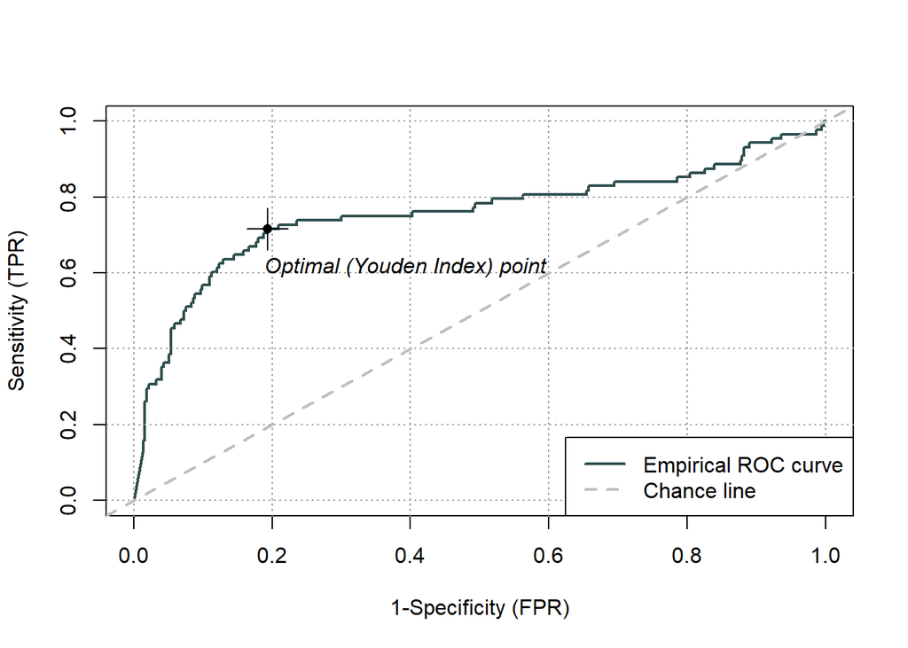

```r
# Predictions
nb_predictions <- predict(nb_model, newdata = test_data, type = "raw")

actual <- test_data$status_oh

roc_nb = rocit(nb_predictions[, 2], actual)
plot(roc_nb)
```

```r
cutoff_index <- which.max(roc_nb$TPR - roc_nb$FPR)
optimal_cutoff <- roc_nb$Cutoff[cutoff_index]

predicted_class_nb <- ifelse(nb_predictions[, 2] >= optimal_cutoff, 1, 0)

confusionMatrix(as.factor(predicted_class_nb), as.factor(test_data$status_oh))
```

```
## Confusion Matrix and Statistics
##
##           Reference
## Prediction   0   1
##          0 301  25
##          1  72  63
##
##                Accuracy : 0.7896
##                  95% CI : (0.7495, 0.8259)
##     No Information Rate : 0.8091
##     P-Value [Acc > NIR] : 0.8693
##
##                   Kappa : 0.4343
##
##  Mcnemar's Test P-Value : 3.003e-06
##
##             Sensitivity : 0.8070
##             Specificity : 0.7159
##          Pos Pred Value : 0.9233
##          Neg Pred Value : 0.4667
##              Prevalence : 0.8091
##          Detection Rate : 0.6529
##    Detection Prevalence : 0.7072
##       Balanced Accuracy : 0.7614
##
##        'Positive' Class : 0
##
```

Accuracy: 78,96%. H0 zamietame. mean - ([,1]) a standard deviation - ([,2]) pre každú triedu (0 and 1).

# LDA metóda

```r
# Model
lda_model <- lda(status_oh ~ `percentage expenditure` + GDP, data = train_data)
lda_model
```

```
## Call:
## lda(status_oh ~ `percentage expenditure` + GDP, data = train_data)
##
## Prior probabilities of groups:
##         0         1
## 0.8195652 0.1804348
##
## Group means:
##   `percentage expenditure`       GDP
## 0                 395.8681  4040.071
## 1                3310.3655 22614.937
##
## Coefficients of linear discriminants:
##                                   LD1
## `percentage expenditure` 0.0003325649
## GDP                      0.0000307097
```

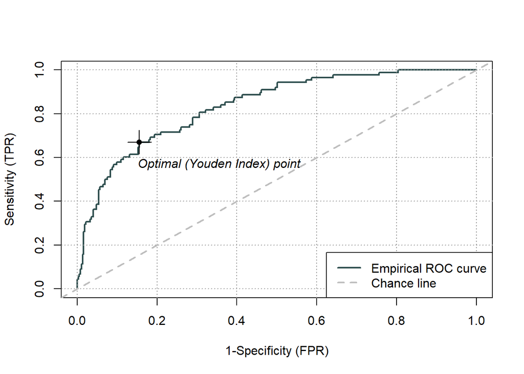

```r
# Predictions

lda_predictions <- predict(lda_model, newdata = test_data)$posterior[, "1"]

actual <- test_data$status_oh

roc_lda = rocit(lda_predictions, actual)
plot(roc_lda)
```

```r
cutoff_index <- which.max(roc_lda$TPR - roc_lda$FPR)
optimal_cutoff <- roc_lda$Cutoff[cutoff_index]

predicted_class_lda <- ifelse(lda_predictions >= optimal_cutoff, 1, 0)

confusionMatrix(as.factor(predicted_class_lda), as.factor(test_data$status_oh))
```

```
## Confusion Matrix and Statistics
##
##           Reference
## Prediction   0   1
##          0 315  29
##          1  58  59
##
##                Accuracy : 0.8113
##                  95% CI : (0.7725, 0.846)
##     No Information Rate : 0.8091
##     P-Value [Acc > NIR] : 0.481238
##
##                   Kappa : 0.4574
##
##  Mcnemar's Test P-Value : 0.002683
##
##             Sensitivity : 0.8445
##             Specificity : 0.6705
##          Pos Pred Value : 0.9157
##          Neg Pred Value : 0.5043
##              Prevalence : 0.8091
##          Detection Rate : 0.6833
##    Detection Prevalence : 0.7462
##       Balanced Accuracy : 0.7575
##
##        'Positive' Class : 0
##
```

Accuracy: 81,13%. H0 zamietame.

## Random Forest

```r
library(randomForest)
train_data_rf = train_data %>%
  dplyr::select(status_oh, `percentage expenditure`, GDP) %>%
  mutate(PE = `percentage expenditure`) %>%
  drop_na()
test_data_rf = test_data %>%
  dplyr::select(status_oh, `percentage expenditure`, GDP) %>%
  mutate(PE = `percentage expenditure`) %>%
  drop_na()
# Model
rf_model <- randomForest(status_oh ~ PE + GDP, data = train_data_rf)
rf_model
```

```
##
## Call:
##  randomForest(formula = status_oh ~ PE + GDP, data = train_data_rf)
##                Type of random forest: regression
##                      Number of trees: 500
## No. of variables tried at each split: 1
##
##           Mean of squared residuals: 0.1046655
##                     % Var explained: 29.22
```

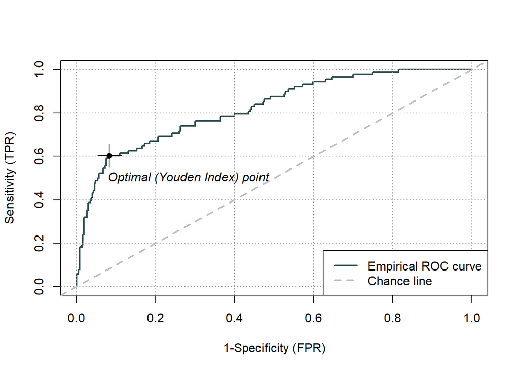

```r
# Predictions
rf_predictions <- predict(rf_model, test_data_rf)

actual <- test_data_rf$status_oh
roc_random_forrest = rocit(rf_predictions, actual)
plot(roc_random_forrest)
```

```r
cutoff_index <- which.max(roc_random_forrest$TPR + (1 - roc_random_forrest$FPR) - 1)
optimal_cutoff <- roc_random_forrest$Cutoff[cutoff_index]
optimal_cutoff
```

```
## [1] 0.3802667
```

```r
predicted_class_randomm_forrest <- ifelse(rf_predictions >= optimal_cutoff, 1, 0)


confusionMatrix(as.factor(predicted_class_randomm_forrest), as.factor(test_data_rf$status_oh))
```

```
## Confusion Matrix and Statistics
##
##           Reference
## Prediction   0   1
##          0 342  35
##          1  31  53
##
##                Accuracy : 0.8568
##                  95% CI : (0.8215, 0.8875)
##     No Information Rate : 0.8091
##     P-Value [Acc > NIR] : 0.004337
##
##                   Kappa : 0.5283
##
##  Mcnemar's Test P-Value : 0.711923
##
##             Sensitivity : 0.9169
##             Specificity : 0.6023
##          Pos Pred Value : 0.9072
##          Neg Pred Value : 0.6310
##              Prevalence : 0.8091
##          Detection Rate : 0.7419
##    Detection Prevalence : 0.8178
##       Balanced Accuracy : 0.7596
##
##        'Positive' Class : 0
##
```

Accuracy: 85,68%. H0 zamietame.

## Model performance parameters v 1 tabuľke pre 3. experiment

```r
library(pROC)

test_data$status_oh <- as.factor(test_data$status_oh)
test_data_rf$status_oh <- as.factor(test_data_rf$status_oh)

# Calculate performance metrics
data.frame(
  Model = c("GLM","LDA", "SVM-linear","SVM-radial", "Naive Bayes", "Random Forest"),
  Accuracy = c(
    confusionMatrix(as.factor(predicted_class), test_data$status_oh)$overall["Accuracy"],
    confusionMatrix(as.factor(predicted_class_lda), test_data$status_oh)$overall["Accuracy"],
    confusionMatrix(as.factor(predicted_class_svm_ln), test_data$status_oh)$overall["Accuracy"],
    confusionMatrix(as.factor(predicted_class_svm_rad), test_data$status_oh)$overall["Accuracy"],
    confusionMatrix(as.factor(predicted_class_nb), test_data$status_oh)$overall["Accuracy"],
    confusionMatrix(as.factor(predicted_class_randomm_forrest), test_data_rf$status_oh)$overall["Accuracy"]
  ),
  Sensitivity = c(
    confusionMatrix(as.factor(predicted_class), test_data$status_oh)$byClass["Sensitivity"],
    confusionMatrix(as.factor(predicted_class_lda), test_data$status_oh)$byClass["Sensitivity"],
    confusionMatrix(as.factor(predicted_class_svm_ln), test_data$status_oh)$byClass["Sensitivity"],
    confusionMatrix(as.factor(predicted_class_svm_rad), test_data$status_oh)$byClass["Sensitivity"],
    confusionMatrix(as.factor(predicted_class_nb), test_data$status_oh)$byClass["Sensitivity"],
    confusionMatrix(as.factor(predicted_class_randomm_forrest), test_data_rf$status_oh)$byClass["Sensitivity"]
  ),
  Specificity = c(
    confusionMatrix(as.factor(predicted_class), test_data$status_oh)$byClass["Specificity"],
    confusionMatrix(as.factor(predicted_class_lda), test_data$status_oh)$byClass["Specificity"],
    confusionMatrix(as.factor(predicted_class_svm_ln), test_data$status_oh)$byClass["Specificity"],
    confusionMatrix(as.factor(predicted_class_svm_rad), test_data$status_oh)$byClass["Specificity"],
    confusionMatrix(as.factor(predicted_class_nb), test_data$status_oh)$byClass["Specificity"],
    confusionMatrix(as.factor(predicted_class_randomm_forrest), test_data_rf$status_oh)$byClass["Specificity"]
  ),
  F1_Score = c(
    confusionMatrix(as.factor(predicted_class), test_data$status_oh)$byClass["F1"],
    confusionMatrix(as.factor(predicted_class_lda), test_data$status_oh)$byClass["F1"],
    confusionMatrix(as.factor(predicted_class_svm_ln), test_data$status_oh)$byClass["F1"],
    confusionMatrix(as.factor(predicted_class_svm_rad), test_data$status_oh)$byClass["F1"],
    confusionMatrix(as.factor(predicted_class_nb), test_data$status_oh)$byClass["F1"],
    confusionMatrix(as.factor(predicted_class_randomm_forrest), test_data_rf$status_oh)$byClass["F1"]
  ),
  AUC_ROC = c(
    roc(test_data$status_oh, as.numeric(predicted_class))$auc,
    roc(test_data$status_oh, as.numeric(predicted_class_lda))$auc,
    roc(test_data$status_oh, as.numeric(predicted_class_svm_ln))$auc,
    roc(test_data$status_oh, as.numeric(predicted_class_svm_rad))$auc,
    roc(test_data$status_oh, as.numeric(predicted_class_nb))$auc,
    roc(test_data_rf$status_oh, as.numeric(predicted_class_randomm_forrest))$auc
  )
)
```

```
##           Model  Accuracy Sensitivity Specificity  F1_Score   AUC_ROC
## 1           GLM 0.8112798   0.8445040   0.6704545 0.8786611 0.7574793
## 2           LDA 0.8112798   0.8445040   0.6704545 0.8786611 0.7574793
## 3    SVM-linear 0.8438178   0.8927614   0.6363636 0.9024390 0.7645625
## 4    SVM-radial 0.8047722   0.8310992   0.6931818 0.8732394 0.7621405
## 5   Naive Bayes 0.7895879   0.8069705   0.7159091 0.8612303 0.7614398
## 6 Random Forest 0.8568330   0.9168901   0.6022727 0.9120000 0.7595814
```

Modely Random Forest a SVM-lienar maju najvyššiu presnosť zo všetkých modelov (0,85 a 0,8438). Model Naive Bayes má najnižšiu presnosť (0,789).

Model Random Forest má najvyššiu citlivosť (0,9168), čo naznačuje, že efektívne identifikuje pozitívne prípady. Model Random Forest majú výrazne nižšiu špecificitu (0,6022), čo naznačuje, že neefektívne identifikuje negatívne prípady. Metrika AUCROC je približne rovnaká pre všetky modely.

- pairplot kombinácie percentage expenditure a Schooling

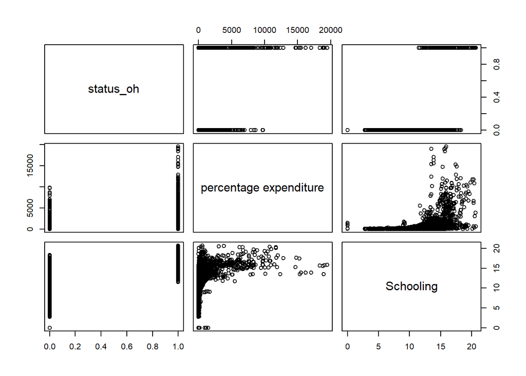

```r
data %$% pairs(status_oh ~  `percentage expenditure` + Schooling)
```